{% raw %}

```python
from fastai2.basics import *
from fastai2.callback.all import *
from fastai2.vision.all import *
```

```python
# all_slow
```

## Single-label classification

### Gathering the data

We use the data block API to get our data in a `DataLoaders`. Here our inputs are images and our targets categories. The images are all in a folder, so we use `get_image_files` to collect them all, a `RandomSplitter` to split between training and validation, then we get the label from the filenames with a regex labeller.

```python
pets = DataBlock(blocks=(ImageBlock, CategoryBlock),
                 get_items=get_image_files,
                 splitter=RandomSplitter(),
                 get_y=RegexLabeller(pat = r'/([^/]+)_\d+.jpg$'),
                 item_tfms=Resize(460),
                 batch_tfms=aug_transforms(size=224, max_rotate=30, min_scale=0.75))
```

```python
dls = pets.dataloaders(untar_data(URLs.PETS)/"images",  bs=32)
```

Then we can look at some of our pictures with `dls.show_batch()`

```python
len(dls.train_ds.items)
```

```
5912
```

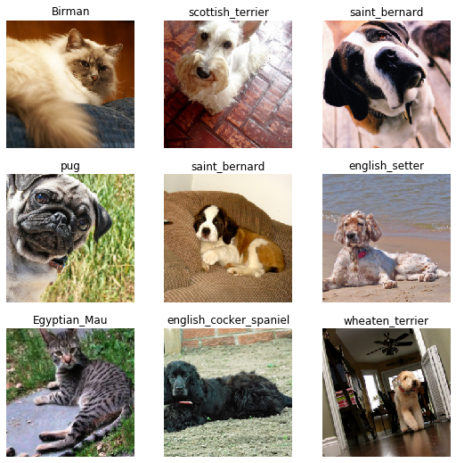

```python
dls.show_batch(max_n=9)
```

### Using a pretrained model

First let's import a `resnet34` form torchvision.

```python
from torchvision.models import resnet34,resnet50
```

```python
#from fastai2.vision.models.xresnet import xresnet50
```

We will use the AdamW optimizer (Adam with true weight decay).

```python
opt_func = partial(Adam, lr=slice(3e-3), wd=0.01, eps=1e-8)
```

```python
#Or use Ranger
#def opt_func(p, lr=slice(3e-3)): return Lookahead(RAdam(p, lr=lr, mom=0.95, wd=0.01))
```

Then we can call `cnn_learner` to build a `Learner` from our `DataLoaders`. Since we are using a pretrained model, it comes automatically frozen, which means only the head is going to be trained.

```python
learn = cnn_learner(dls, resnet50, opt_func=opt_func, metrics=error_rate, config=cnn_config(ps=0.33)).to_fp16()
```

We can train the head a little bit using the 1cycle policy.

```python
learn.fit_one_cycle(1)
```

| epoch | train_loss | valid_loss | error_rate | time |
| --- | --- | --- | --- | --- |
| 0 | 0.539979 | 0.260939 | 0.084574 | 00:24 |

Then we can unfreeze the model and use discriminative learning rates.

```python
learn.unfreeze()
# learn.fit_one_cycle(4, slice(1e-5, 1e-3))
learn.fit_one_cycle(1, slice(1e-5, 1e-3))
```

| epoch | train_loss | valid_loss | error_rate | time |
| --- | --- | --- | --- | --- |
| 0 | 0.480262 | 0.255037 | 0.082544 | 00:31 |

### Seeing results

```python
fname = dls.train_ds.items[0]
```

```python
learn.predict(fname)
```

```
('Russian_Blue',
 tensor(9),
 tensor([3.2060e-04, 4.6202e-06, 1.6596e-04, 9.3935e-02, 1.7009e-01, 2.0974e-04,
         2.1056e-04, 4.9679e-04, 6.3355e-04, 7.3025e-01, 4.8957e-04, 3.2960e-05,
         9.3550e-05, 4.3036e-04, 9.2063e-06, 2.8626e-04, 6.1277e-05, 9.9583e-05,
         1.1156e-04, 5.2107e-05, 3.9530e-04, 1.6063e-05, 1.0351e-05, 1.0120e-04,
         1.2156e-04, 1.9338e-05, 8.3837e-05, 5.4829e-04, 1.4427e-05, 1.2248e-04,
         4.9762e-06, 1.0287e-04, 7.7992e-05, 6.1068e-05, 1.0534e-04, 1.7529e-04,
         5.1625e-05]))
```

```python
learn.export()
learn1 = load_learner('export.pkl')
```

```python
img = PILImage.create(fname)
```

```python
learn1.show_results(max_n=9)
```

[output not shown]

```python
interp = Interpretation.from_learner(learn1)
```

```python
interp.plot_top_losses(9, figsize=(15,10))
```

[output not shown]

## Multi-label classification

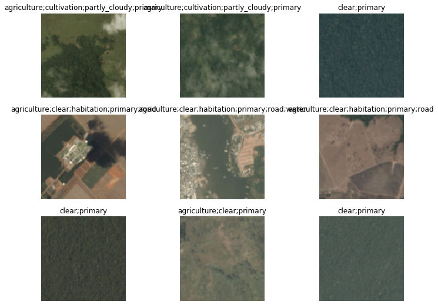

```python
planet_source = untar_data(URLs.PLANET_TINY)
df = pd.read_csv(planet_source/"labels.csv")

planet = DataBlock(blocks=(ImageBlock, MultiCategoryBlock),
                   get_x=lambda x:planet_source/"train"/f'{x[0]}.jpg',
                   splitter=RandomSplitter(),
                   get_y=lambda x:x[1].split(' '),
                   batch_tfms=aug_transforms(flip_vert=True, max_lighting=0.1, max_zoom=1.05, max_warp=0.))

dls = planet.dataloaders(df.values)
dls.show_batch(max_n=9, figsize=(12,9))
```

```python
learn = cnn_learner(dls, resnet34, metrics=accuracy_multi)
learn.fit_one_cycle(1)
```

| epoch | train_loss | valid_loss | accuracy_multi | time |
| --- | --- | --- | --- | --- |
| 0 | 1.103069 | 0.649033 | 0.610714 | 00:02 |

```python
learn.predict(planet_source/f'train/train_10030.jpg')
```

```
((#5) ['bare_ground','clear','cloudy','cultivation','road'],
 tensor([False, False,  True, False,  True,  True,  True, False, False, False,
         False,  True, False, False]),
 tensor([0.4993, 0.2256, 0.6531, 0.3821, 0.7002, 0.6430, 0.6785, 0.4854, 0.2270,
         0.4699, 0.4722, 0.7407, 0.1130, 0.1830]))
```

```python
learn.tta(use_max=True)
```

[output not shown]

```python
img = PILImage.create(planet_source/f'train/train_10030.jpg')
```

```python
learn.predict(img)
```

[output not shown]

```python
learn.show_results(max_n=9)
```

[output not shown]

```python
interp = Interpretation.from_learner(learn)
```

```python
interp.plot_top_losses(9)
```

[output not shown]

## Segmentation

```python
codes = np.loadtxt(untar_data(URLs.CAMVID_TINY)/'codes.txt', dtype=str)
def get_y(o): return path/'labels'/f'{o.stem}_P{o.suffix}'
```

```python
path = untar_data(URLs.CAMVID_TINY)
camvid = DataBlock(blocks=(ImageBlock, MaskBlock(codes)),
                   get_items=get_image_files,
                   splitter=RandomSplitter(),
                   get_y=get_y,
                   batch_tfms=aug_transforms())
dls = camvid.dataloaders(path/"images", bs=8)
```

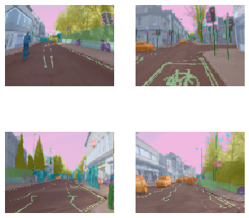

```python
dls.show_batch(max_n=4)
```

```python
learn = unet_learner(dls, resnet34)
# learn.fine_tune(1, 1e-3)
# Use the below to get somewhat reasonable results - but takes a bit longer
learn.fine_tune(8)
```

| epoch | train_loss | valid_loss | time |
| --- | --- | --- | --- |
| 0 | 3.179228 | 2.465636 | 00:03 |

| epoch | train_loss | valid_loss | time |
| --- | --- | --- | --- |
| 0 | 1.901250 | 1.653285 | 00:03 |
| 1 | 1.711994 | 1.312719 | 00:03 |
| 2 | 1.580556 | 1.334425 | 00:03 |
| 3 | 1.473224 | 1.062041 | 00:03 |
| 4 | 1.361964 | 0.974751 | 00:03 |
| 5 | 1.267812 | 0.875766 | 00:03 |
| 6 | 1.183181 | 0.829208 | 00:03 |
| 7 | 1.119537 | 0.817423 | 00:03 |

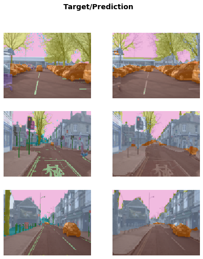

```python
learn.show_results(max_n=6, figsize=(7,8))
```

## Points

```python
path = untar_data(URLs.BIWI_SAMPLE)
fn2ctr = (path/'centers.pkl').load()
```

```python
biwi = DataBlock(blocks=(ImageBlock, PointBlock),
                 get_items = get_image_files,
                 get_y = lambda o:fn2ctr[o.name].flip(0),
                 splitter=RandomSplitter(),
                 batch_tfms=[*aug_transforms(size=(120,160)), Normalize.from_stats(*imagenet_stats)])
```

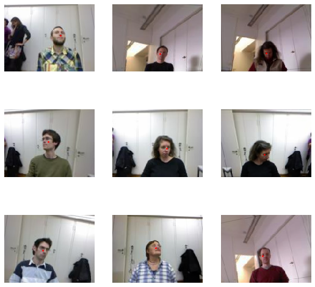

```python
dls = biwi.dataloaders(path)
dls.show_batch(max_n=9, vmin=1, vmax=30)
```

```python
#TODO: look for attrs in after_item
dls.c = dls.after_item.c
dls.train_ds.loss_func = MSELossFlat()
```

```python
learn = cnn_learner(dls, resnet34)
learn.fit_one_cycle(3, 1e-3)
```

| epoch | train_loss | valid_loss | time |
| --- | --- | --- | --- |
| 0 | 4.653057 | 9.390870 | 00:02 |
| 1 | 4.398911 | 4.525988 | 00:02 |
| 2 | 4.363518 | 3.165001 | 00:02 |

```python
learn.predict(dls.train_ds.items[0])
```

```
(tensor([[ 13.2822, 167.8245]]),
 tensor([-0.8340,  1.7971]),
 tensor([-0.8340,  1.7971]))
```

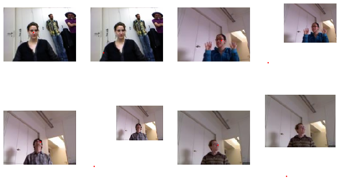

```python
learn.show_results(max_n=4)
```

## fin

{% endraw %}